# Akanksha_NLP2

## **Problem Statement**

### **Business Context**

In today's dynamic business landscape, organizations are increasingly recognizing the pivotal role customer feedback plays in shaping the trajectory of their products and services. The ability to **swiftly and effectively respond to customer input** not only fosters enhanced customer experiences but also serves as a catalyst for growth, prolonged customer engagement, and the nurturing of lifetime value relationships.

As a dedicated Product Manager or Product Analyst, staying attuned to the voice of your customers is not just a best practice; it's a strategic imperative.

While your organization may be inundated with a wealth of customer-generated feedback and support tickets, your role entails much more than just processing these inputs. To make your efforts in managing customer experience and expectations truly impactful, you need a structured approach – a method that allows you to discern the most pressing issues, set priorities, and allocate resources judiciously.

One of the most effective strategies at your disposal as an organization is to harness the power of automated Support Ticket Categorization - **done in the modern day using Large Language Models and Generative AI.**

### **Objective**

Develop a Generative AI application using a Large Language Model to **automate the classification and processing of support tickets.** The application will aim to predict ticket categories, assign priority, suggest estimated resolution times, generate responses based on sentiment analysis, and store the results in a structured DataFrame.

## **Please read the instructions carefully before starting the project.**

This is a commented Python Notebook file in which all the instructions and tasks to be performed are mentioned.

- Blanks '**___**' are provided in the notebook that needs to be filled with an appropriate code to get the correct result. With every '**___**' blank, there is a comment that briefly describes what needs to be filled in the blank space.
- Identify the task to be performed correctly, and only then proceed to write the required code.
- Please run the codes in a sequential manner from the beginning to avoid any unnecessary errors.
- Add the results/observations (wherever mentioned) derived from the analysis in the presentation and submit the same. Any mathematical or computational details which are a graded part of the project can be included in the Appendix section of the presentation.

## **Installing and Importing Necessary Libraries and Dependencies**

```python
# Installation for GPU llama-cpp-python
!CMAKE_ARGS="-DLLAMA_CUBLAS=on" FORCE_CMAKE=1 pip install llama-cpp-python --force-reinstall --upgrade --no-cache-dir -q
```

[output not shown]

```python
# Install the hugging face hub
!pip install huggingface_hub -q
```

```python
# Importing library for data manipulation
import pandas as pd

# Function to download the model from the Hugging Face model hub
from huggingface_hub import hf_hub_download

# Importing the json module
import json
```

```python
# Importing the Llama class from the llama_cpp module
from llama_cpp import Llama
```

## **Loading the Dataset**

```python
from google.colab import drive
drive.mount('/content/drive')
```

```python
# Complete the code to read the CSV file
data = pd.read_csv("/content/drive/MyDrive/Colab Notebooks/NLP/Support_ticket_text_data_mid_term (5).csv")
```

## **Data Overview**

```python
# Write the code to check the first 5 rows of the data
data.head()
```

|  | support_tick_id | support_ticket_text |
| --- | --- | --- |
| 0 | ST2023-006 | My internet connection has significantly slowe... |
| 1 | ST2023-007 | Urgent help required! My laptop refuses to sta... |
| 2 | ST2023-008 | I've accidentally deleted essential work docum... |
| 3 | ST2023-009 | Despite being in close proximity to my Wi-Fi r... |
| 4 | ST2023-010 | My smartphone battery is draining rapidly, eve... |

```python
# Write the code to check the shape of the data
data.shape
```

```
(21, 2)
```

```python
# Write the code to check for missing values in the data
data.isna().sum()
```

```
support_tick_id        0
support_ticket_text    0
dtype: int64
```

## **Model Building**

### Loading the model

```python
model_name_or_path = "TheBloke/Llama-2-13B-chat-GGUF"
model_basename = "llama-2-13b-chat.Q5_K_M.gguf" # the model is in gguf format
```

```python
# Using hf_hub_download to download a model from the Hugging Face model hub
# The repo_id parameter specifies the model name or path in the Hugging Face repository
# The filename parameter specifies the name of the file to download
model_path = hf_hub_download(
    repo_id = model_name_or_path ,    # complete the code to mentioned the repo_id
    filename = model_basename    # complete the code to mentioned the filename
)

print(model_path)
```

```
/root/.cache/huggingface/hub/models--TheBloke--Llama-2-13B-chat-GGUF/snapshots/4458acc949de0a9914c3eab623904d4fe999050a/llama-2-13b-chat.Q5_K_M.gguf
```

```python
# complete the code to create an instance of the 'Llama' class with specified parameters

lcpp_llm = Llama(
    model_path=model_path,
    n_threads=2,  # CPU cores
    n_batch=512,  # Should be between 1 and n_ctx, consider the amount of VRAM in your GPU.
    n_gpu_layers=43,  # Change this value based on your model and your GPU VRAM pool.
    n_ctx=4096,  # Context window
)
```

[output not shown]

[output cut: 32 more lines]

[output not shown]

### Defining Model Response Parameters

```python
def generate_llama_response(instruction, review):

    # System message explicitly instructing not to include the review text
    system_message = """
        [INST]<<SYS>>
        {}
        <</SYS>>[/INST]
    """.format(instruction)

    # Combine user_prompt and system_message to create the prompt
    prompt = f"{review}\n{system_message}"

    # Generate a response from the LLaMA model
    response = lcpp_llm(
        prompt=prompt,
        max_tokens=1024,
        temperature=0.01,
        top_p=0.95,
        repeat_penalty=1.2,
        top_k=50,
        stop=['INST'],
        echo=False,
        seed=42,
    )

    # Extract the sentiment from the response
    response_text = response["choices"][0]["text"]
    return response_text
```

## **Task 1: Ticket Categorization**

```python
# create a copy of the data
data_1 = data.copy()
```

```python
## Complete the prompt to get the desired output
instruction_1 = """
  You are an AI analyzing support Ticket Categorization. Classify the category of the provided review into the following categories:
    - technical issues
    - hardware issues
    - data recovery
"""
```

```python
data_1['llama_response'] = data_1['support_ticket_text'].apply(lambda x: generate_llama_response(instruction_1,x))
```

[output not shown]

[output cut: 90 more lines]

[output not shown]

```python
# Write the code to check the first five rows of the data to confirm whether the new column has been added
data_1.head()
```

|  | support_tick_id | support_ticket_text | llama_response |
| --- | --- | --- | --- |
| 0 | ST2023-006 | My internet connection has significantly slowe... | Based on the information provided in the revi... |
| 1 | ST2023-007 | Urgent help required! My laptop refuses to sta... | Based on the information provided in the revi... |
| 2 | ST2023-008 | I've accidentally deleted essential work docum... | Based on the content of your message, I would... |
| 3 | ST2023-009 | Despite being in close proximity to my Wi-Fi r... | Based on the information provided in the revi... |
| 4 | ST2023-010 | My smartphone battery is draining rapidly, eve... | Based on the information provided in the revi... |

```python
def extract_category(model_response):
    if 'technical issues' in model_response.lower():
        return 'Technical issues'
    elif 'hardware issues' in model_response.lower():
        return 'Hardware issues'
    elif 'data recovery' in model_response.lower():
        return 'Data recovery'
```

```python
data_1['Category'] = data_1['llama_response'].apply(extract_category)
data_1['Category'].head()
```

```
0    Technical issues
1    Technical issues
2       Data recovery
3    Technical issues
4     Hardware issues
Name: Category, dtype: object
```

```python
final_data_1 = data_1.drop(['llama_response'], axis=1)
final_data_1.head()
```

|  | support_tick_id | support_ticket_text | Category |
| --- | --- | --- | --- |
| 0 | ST2023-006 | My internet connection has significantly slowe... | Technical issues |
| 1 | ST2023-007 | Urgent help required! My laptop refuses to sta... | Technical issues |
| 2 | ST2023-008 | I've accidentally deleted essential work docum... | Data recovery |
| 3 | ST2023-009 | Despite being in close proximity to my Wi-Fi r... | Technical issues |
| 4 | ST2023-010 | My smartphone battery is draining rapidly, eve... | Hardware issues |

```python
final_data_1['Category'].value_counts()
```

```
Technical issues    9
Data recovery       7
Hardware issues     5
Name: Category, dtype: int64
```

## **Task 2: Ticket Categorization and Returning Structured Output**

```python
# defining a function to parse the JSON output from the model
def extract_json_data(json_str):
    try:
        # Find the indices of the opening and closing curly braces
        json_start = json_str.find('{')
        json_end = json_str.rfind('}')

        if json_start != -1 and json_end != -1:
            extracted_category = json_str[json_start:json_end + 1]  # Extract the JSON object
            data_dict = json.loads(extracted_category)
            return data_dict
        else:
            print(f"Warning: JSON object not found in response: {json_str}")
            return {}
    except json.JSONDecodeError as e:
        print(f"Error parsing JSON: {e}")
        return {}
```

```python
# create a copy of the data
data_2 = data.copy()
```

```python
## Complete the prompt to get the desired output
instruction_2 = """
  You are an AI analyzing support Ticket Categorization. Classify the category of the provided review into the following categories:
    - technical issues
    - hardware issues
    - data recovery

    Format the output as a JSON object with a single key-value pair as shown below:
    {"Category": "category prediction"}
"""
```

```python
data_2['llama_response'] = data_2['support_ticket_text'].apply(lambda x: generate_llama_response(instruction_2,x))
```

[output not shown]

[output cut: 92 more lines]

[output not shown]

```python
# Write the code to check the first five rows of the data to confirm whether the new column has been added
data_2.head()
```

|  | support_tick_id | support_ticket_text | llama_response |
| --- | --- | --- | --- |
| 0 | ST2023-006 | My internet connection has significantly slowe... | Sure! Based on the information provided in th... |
| 1 | ST2023-007 | Urgent help required! My laptop refuses to sta... | {\n "Category": "hardware issues"\n } |
| 2 | ST2023-008 | I've accidentally deleted essential work docum... | Sure! Based on the content of your message, I... |
| 3 | ST2023-009 | Despite being in close proximity to my Wi-Fi r... | Sure! Based on the information provided in th... |
| 4 | ST2023-010 | My smartphone battery is draining rapidly, eve... | Sure! Based on the information provided in th... |

```python
data_2['llama_response_parsed'] = data_2['llama_response'].apply(extract_json_data)
data_2['llama_response_parsed'].head()
```

```
0    {'Category': 'technical issues'}
1     {'Category': 'hardware issues'}
2       {'Category': 'data recovery'}
3    {'Category': 'technical issues'}
4     {'Category': 'hardware issues'}
Name: llama_response_parsed, dtype: object
```

```python
llama_response_parsed_df_2 = pd.json_normalize(data_2['llama_response_parsed'])
llama_response_parsed_df_2.head()
```

|  | Category |
| --- | --- |
| 0 | technical issues |
| 1 | hardware issues |
| 2 | data recovery |
| 3 | technical issues |
| 4 | hardware issues |

```python
data_with_parsed_model_output_2 = pd.concat([data_2, llama_response_parsed_df_2], axis=1)
data_with_parsed_model_output_2.head()
```

|  | support_tick_id | support_ticket_text | llama_response | llama_response_parsed | Category |
| --- | --- | --- | --- | --- | --- |
| 0 | ST2023-006 | My internet connection has significantly slowe... | Sure! Based on the information provided in th... | {'Category': 'technical issues'} | technical issues |
| 1 | ST2023-007 | Urgent help required! My laptop refuses to sta... | {\n "Category": "hardware issues"\n } | {'Category': 'hardware issues'} | hardware issues |
| 2 | ST2023-008 | I've accidentally deleted essential work docum... | Sure! Based on the content of your message, I... | {'Category': 'data recovery'} | data recovery |
| 3 | ST2023-009 | Despite being in close proximity to my Wi-Fi r... | Sure! Based on the information provided in th... | {'Category': 'technical issues'} | technical issues |
| 4 | ST2023-010 | My smartphone battery is draining rapidly, eve... | Sure! Based on the information provided in th... | {'Category': 'hardware issues'} | hardware issues |

```python
final_data_2 = data_with_parsed_model_output_2.drop(['llama_response','llama_response_parsed'], axis=1)
final_data_2.head()
```

|  | support_tick_id | support_ticket_text | Category |
| --- | --- | --- | --- |
| 0 | ST2023-006 | My internet connection has significantly slowe... | technical issues |
| 1 | ST2023-007 | Urgent help required! My laptop refuses to sta... | hardware issues |
| 2 | ST2023-008 | I've accidentally deleted essential work docum... | data recovery |
| 3 | ST2023-009 | Despite being in close proximity to my Wi-Fi r... | technical issues |
| 4 | ST2023-010 | My smartphone battery is draining rapidly, eve... | hardware issues |

## **Task 3: Ticket Categorization, Creating Tags, and Returning Structured Output**

```python
# create a copy of the data
data_3 = data.copy()
```

```python
## Complete the prompt to get the desired output
instruction_3 = """
  You are an AI analyzing support Ticket Categorization. Classify the category of the provided review into the following categories:
    - technical issues
    - hardware issues
    - data recovery

Once it is done, as an AI analyzing support Ticket categorization, classify the relevant tags as per the category(Technical/Hardware/data recovery). You can select one or more than 1 tag also.:
{
    "Tags": [
        "Performance Issue",
        "Configuration Issue",
        "Security Issue",
        "Windows",
        "MacOS",
        "Linux",
        "Android",
        "iOS",
        "Frontend",
        "Backend",
        "Database",
        "API",
        "User Interface",
        "Production",
        "Development",
        "Staging",
        "Testing",
        "Sales",
        "Marketing",
        "Customer Support",
        "Engineering",
        "Desktop",
        "Laptop",
        "Server",
        "Printer",
        "Scanner",
        "Router",
        "Switch",
        "CPU",
        "GPU",
        "RAM",
        "Hard Drive/SSD",
        "Motherboard",
        "Power Supply",
        "Display/Monitor",
        "Keyboard",
        "Mouse",
        "Overheating",
        "No Power",
        "Slow Performance",
        "Hardware Failure",
        "Connectivity Issue",
        "Display Issue",
        "Input Device Issue",
        "Noise/Vibration",
        "Office",
        "Data Center",
        "Remote Site",
        "Client Site",
        "Employee Name or ID",
        "Department or Team Affected",
        "Under Warranty",
        "Out of Warranty",
        "Under Maintenance Contract",
        "Not Under Maintenance Contract",
        "Device Serial Number",
        "Asset Tag Number",
        "Accidental Deletion",
        "File Corruption",
        "Disk Failure",
        "Virus/Malware Attack",
        "Formatted Drive",
        "Partition Loss",
        "Hard Drive",
        "External Drive",
        "USB Flash Drive",
        "Memory Card",
        "RAID Array",
        "NAS (Network Attached Storage)",
        "Cloud Storage",
        "Documents",
        "Photos",
        "Videos",
        "Music",
        "Databases",
        "Emails",
        "Software-Based Recovery",
        "Hardware-Based Recovery",
        "Remote Data Recovery",
        "On-Site Data Recovery",
        "Backup Restoration",
        "Backup Available",
        "No Backup Available",
        "User Name or ID",
        "Department or Team Affected",
        "Network connectivity issues",
        "Internet/Network",
        "Network infrastructure",
        "Home/Remote",
        "Individual user"
    ]
}




Output the overall Ticket Categorization for each category in a JSON format with the following keys:
    {
        "Category": "Category",
        "Tags" : "Tag"
    }

    Only return the JSON, do not return any other information.


   """
```

```python
data_3['llama_response'] = data_3['support_ticket_text'].apply(lambda x: generate_llama_response(instruction_3,x))
```

[output not shown]

[output cut: 92 more lines]

[output not shown]

```python
# Write the code to check the first five rows of the data to confirm whether the new column has been added
data_3.head()
```

|  | support_tick_id | support_ticket_text | llama_response |
| --- | --- | --- | --- |
| 0 | ST2023-006 | My internet connection has significantly slowe... | {\n"Category": "Technical",\n"Tags": ["Perfor... |
| 1 | ST2023-007 | Urgent help required! My laptop refuses to sta... | {\n"Category": "Hardware Issues",\n"Tags": ["... |
| 2 | ST2023-008 | I've accidentally deleted essential work docum... | \n{\n"Category": "data recovery",\n"Tags": ["H... |
| 3 | ST2023-009 | Despite being in close proximity to my Wi-Fi r... | {\n"Category": "Technical",\n"Tags": ["Perfor... |
| 4 | ST2023-010 | My smartphone battery is draining rapidly, eve... | \n{\n"Category": "Hardware Issues",\n"Tags": [... |

```python
data_3['llama_response_parsed'] = data_3['llama_response'].apply(extract_json_data)
data_3['llama_response_parsed'].head()
```

```
0    {'Category': 'Technical', 'Tags': ['Performanc...
1    {'Category': 'Hardware Issues', 'Tags': ['Lapt...
2    {'Category': 'data recovery', 'Tags': ['Hardwa...
3    {'Category': 'Technical', 'Tags': ['Performanc...
4    {'Category': 'Hardware Issues', 'Tags': ['Hard...
Name: llama_response_parsed, dtype: object
```

```python
llama_response_parsed_df_3 = pd.json_normalize(data_3['llama_response_parsed'])
llama_response_parsed_df_3.head()
```

|  | Category | Tags |
| --- | --- | --- |
| 0 | Technical | [Performance Issue, Configuration Issue, Secur... |
| 1 | Hardware Issues | [Laptop, Performance Issue, Hardware Failure] |
| 2 | data recovery | [Hardware Failure, Accidental Deletion, File C... |
| 3 | Technical | [Performance Issue, Configuration Issue] |
| 4 | Hardware Issues | [Hard Drive/SSD, Motherboard, Power Supply, Di... |

```python
data_with_parsed_model_output_3 = pd.concat([data_3, llama_response_parsed_df_3], axis=1)
data_with_parsed_model_output_3.head()
```

|  | support_tick_id | support_ticket_text | llama_response | llama_response_parsed | Category | Tags |
| --- | --- | --- | --- | --- | --- | --- |
| 0 | ST2023-006 | My internet connection has significantly slowe... | {\n"Category": "Technical",\n"Tags": ["Perfor... | {'Category': 'Technical', 'Tags': ['Performanc... | Technical | [Performance Issue, Configuration Issue, Secur... |
| 1 | ST2023-007 | Urgent help required! My laptop refuses to sta... | {\n"Category": "Hardware Issues",\n"Tags": ["... | {'Category': 'Hardware Issues', 'Tags': ['Lapt... | Hardware Issues | [Laptop, Performance Issue, Hardware Failure] |
| 2 | ST2023-008 | I've accidentally deleted essential work docum... | \n{\n"Category": "data recovery",\n"Tags": ["H... | {'Category': 'data recovery', 'Tags': ['Hardwa... | data recovery | [Hardware Failure, Accidental Deletion, File C... |
| 3 | ST2023-009 | Despite being in close proximity to my Wi-Fi r... | {\n"Category": "Technical",\n"Tags": ["Perfor... | {'Category': 'Technical', 'Tags': ['Performanc... | Technical | [Performance Issue, Configuration Issue] |
| 4 | ST2023-010 | My smartphone battery is draining rapidly, eve... | \n{\n"Category": "Hardware Issues",\n"Tags": [... | {'Category': 'Hardware Issues', 'Tags': ['Hard... | Hardware Issues | [Hard Drive/SSD, Motherboard, Power Supply, Di... |

```python
## Complete the code to drop llama_response and llama_response_parsed variables
final_data_3 = data_with_parsed_model_output_3.drop(['llama_response','llama_response_parsed'], axis=1)
final_data_3.head()
```

|  | support_tick_id | support_ticket_text | Category | Tags |
| --- | --- | --- | --- | --- |
| 0 | ST2023-006 | My internet connection has significantly slowe... | Technical | [Performance Issue, Configuration Issue, Secur... |
| 1 | ST2023-007 | Urgent help required! My laptop refuses to sta... | Hardware Issues | [Laptop, Performance Issue, Hardware Failure] |
| 2 | ST2023-008 | I've accidentally deleted essential work docum... | data recovery | [Hardware Failure, Accidental Deletion, File C... |
| 3 | ST2023-009 | Despite being in close proximity to my Wi-Fi r... | Technical | [Performance Issue, Configuration Issue] |
| 4 | ST2023-010 | My smartphone battery is draining rapidly, eve... | Hardware Issues | [Hard Drive/SSD, Motherboard, Power Supply, Di... |

## **Task 4 - Ticket Categorization, Creating Tags, Assigning Priority, and Returning Structured Output**

```python
# create a copy of the data
data_4 = data.copy()
```

```python
## Complete the prompt to get the desired output
instruction_4 = """
     You are an AI analyzing support Ticket Categorization. Classify the category of the provided review into the following categories:
    - Technical issues
    - Hardware issues
    - Data recovery

Once it is done, as an AI analyzing support Ticket categorization, classify the relevant tags as per the category(Technical/Hardware/data recovery).
You can select one or more than 1 tag also. I category is not found inset Other.
Once it is done, as an AI analyzing support Ticket categorization, classify the relevant tags as per the category(Technical/Hardware/data recovery). You can select one or more than 1 tag also:
Technical_issue_tags = {
    "Category": ["Hardware", "Software", "Network", "Application", "Database"],
    "Type": ["Bug", "Error", "Performance Issue", "Configuration Issue", "Security Issue"],
    "Platform": ["Windows", "MacOS", "Linux", "Android", "iOS"],
    "Component": ["Frontend", "Backend", "Database", "API", "User Interface"],
    "Environment": ["Production", "Development", "Staging", "Testing"],
    "Affected Users/Departments": ["Sales", "Marketing", "Customer Support", "Engineering"]
}

hardware_issue_tags = {
    "Device Type": ["Desktop", "Laptop", "Server", "Printer", "Scanner", "Router", "Switch", "Other"],
    "Component": ["CPU", "GPU", "RAM", "Hard Drive/SSD", "Motherboard", "Power Supply", "Display/Monitor", "Keyboard", "Mouse", "Other"],
    "Issue Description": ["Overheating", "No Power", "Slow Performance", "Hardware Failure", "Connectivity Issue", "Display Issue", "Input Device Issue", "Noise/Vibration", "Other"],
    "Location": ["Office", "Data Center", "Remote Site", "Client Site", "Other"],
    "Affected Users/Departments": ["Employee Name or ID", "Department or Team Affected"],
    "Maintenance Status": ["Under Warranty", "Out of Warranty", "Under Maintenance Contract", "Not Under Maintenance Contract"],
    "Serial Number/Asset Tag": ["Device Serial Number", "Asset Tag Number"]
}

data_recovery_issue_tags = {
    "Data Loss Scenario": ["Accidental Deletion", "File Corruption", "Disk Failure", "Virus/Malware Attack", "Formatted Drive", "Partition Loss", "Other"],
    "Storage Medium": ["Hard Drive", "Solid State Drive (SSD)", "External Drive", "USB Flash Drive", "Memory Card", "RAID Array", "NAS (Network Attached Storage)", "Cloud Storage", "Other"],
    "Data Type": ["Documents", "Photos", "Videos", "Music", "Databases", "Emails", "Other"],
    "Recovery Method": ["Software-Based Recovery", "Hardware-Based Recovery", "Remote Data Recovery", "On-Site Data Recovery", "Backup Restoration", "Other"],
    "Backup Status": ["Backup Available", "No Backup Available", "Backup Status Unknown"],
    "Affected Users/Departments": ["User Name or ID", "Department or Team Affected"]
}


Once that is done, Classify the priority of the review into the following categories:
  -Low
  -Medium
  -High

Do not provide blank output.
Ensure handling missing values appropriately.
Ensure that all values in the JSON are formatted as strings, and each element within the lists should be enclosed in double quotes:

  {
        "Category": "Category prediction",
        "Tags" : ["Tag prediction"],
        "Priority": "Priority prediction"
    }

    Only return the JSON, do not return any other information.
"""
```

```python
# complete the code to create a new column llama_response'
# by applying the generate_llama_response function to each ticket in the 'support_ticket_text' column of the DataFrame 'data_4'
data_4['llama_response'] = data_4['support_ticket_text'].apply(lambda x: generate_llama_response(instruction_4,x))
```

[output not shown]

[output cut: 92 more lines]

[output not shown]

```python
# Write the code to check the first five rows of the data to confirm whether the new column has been added
data_4.head()
```

|  | support_tick_id | support_ticket_text | llama_response |
| --- | --- | --- | --- |
| 0 | ST2023-006 | My internet connection has significantly slowe... | Based on the provided review, I classify the ... |
| 1 | ST2023-007 | Urgent help required! My laptop refuses to sta... | Based on the provided review, I classify the ... |
| 2 | ST2023-008 | I've accidentally deleted essential work docum... | Based on the provided review, I classify the ... |
| 3 | ST2023-009 | Despite being in close proximity to my Wi-Fi r... | Based on the provided review, I classify the ... |
| 4 | ST2023-010 | My smartphone battery is draining rapidly, eve... | Based on the information provided in the revi... |

```python
## Complete the code to apply the extract_json_data function on the llama_response column to create a new column called llama_response_parsed
data_4['llama_response_parsed'] = data_4['llama_response'].apply(extract_json_data)
data_4['llama_response_parsed'].head()
```

```
Error parsing JSON: Extra data: line 10 column 1 (char 269)
```

```
0    {'Category': 'Technical Issues', 'Tags': ['Har...
1    {'Category': 'Hardware Issue', 'Tags': ['Devic...
2    {'Category': 'Data Recovery', 'Tags': ['Data L...
3                                                   {}
4    {'Category': 'Technical Issue', 'Tags': ['Hard...
Name: llama_response_parsed, dtype: object
```

```python
## Complete the code to apply the json_normalize on llama_response_parsed variable
llama_response_parsed_df_4 = pd.json_normalize(data_4['llama_response_parsed'])
llama_response_parsed_df_4.head()
```

|  | Category | Tags | Priority |
| --- | --- | --- | --- |
| 0 | Technical Issues | [Hardware, Network] | Medium |
| 1 | Hardware Issue | [Device Type: Laptop, Issue Description: Overh... | Medium |
| 2 | Data Recovery | [Data Loss Scenario, Storage Medium] | Medium |
| 3 | NaN | NaN | NaN |
| 4 | Technical Issue | [Hardware, Software] | Medium |

```python
llama_response_parsed_df_4['Priority'].value_counts()
```

```
Medium    12
High       8
Name: Priority, dtype: int64
```

```python
## Complete the code to concat data_4 and llama_response_parsed_df_4
data_with_parsed_model_output_4 = pd.concat([data_4, llama_response_parsed_df_4], axis=1)
data_with_parsed_model_output_4.head()
```

|  | support_tick_id | support_ticket_text | llama_response | llama_response_parsed | Category | Tags | Priority |
| --- | --- | --- | --- | --- | --- | --- | --- |
| 0 | ST2023-006 | My internet connection has significantly slowe... | Based on the provided review, I classify the ... | {'Category': 'Technical Issues', 'Tags': ['Har... | Technical Issues | [Hardware, Network] | Medium |
| 1 | ST2023-007 | Urgent help required! My laptop refuses to sta... | Based on the provided review, I classify the ... | {'Category': 'Hardware Issue', 'Tags': ['Devic... | Hardware Issue | [Device Type: Laptop, Issue Description: Overh... | Medium |
| 2 | ST2023-008 | I've accidentally deleted essential work docum... | Based on the provided review, I classify the ... | {'Category': 'Data Recovery', 'Tags': ['Data L... | Data Recovery | [Data Loss Scenario, Storage Medium] | Medium |
| 3 | ST2023-009 | Despite being in close proximity to my Wi-Fi r... | Based on the provided review, I classify the ... | {} | NaN | NaN | NaN |
| 4 | ST2023-010 | My smartphone battery is draining rapidly, eve... | Based on the information provided in the revi... | {'Category': 'Technical Issue', 'Tags': ['Hard... | Technical Issue | [Hardware, Software] | Medium |

```python
## Complete the code to drop llama_response and llama_response_parsed variables
final_data_4 = data_with_parsed_model_output_4.drop(['llama_response','llama_response_parsed'], axis=1)
final_data_4.head()
```

|  | support_tick_id | support_ticket_text | Category | Tags | Priority |
| --- | --- | --- | --- | --- | --- |
| 0 | ST2023-006 | My internet connection has significantly slowe... | Technical Issues | [Hardware, Network] | Medium |
| 1 | ST2023-007 | Urgent help required! My laptop refuses to sta... | Hardware Issue | [Device Type: Laptop, Issue Description: Overh... | Medium |
| 2 | ST2023-008 | I've accidentally deleted essential work docum... | Data Recovery | [Data Loss Scenario, Storage Medium] | Medium |
| 3 | ST2023-009 | Despite being in close proximity to my Wi-Fi r... | NaN | NaN | NaN |
| 4 | ST2023-010 | My smartphone battery is draining rapidly, eve... | Technical Issue | [Hardware, Software] | Medium |

## **Task 5 - Ticket Categorization, Creating Tags, Assigning Priority, Assigning ETA, and Returning Structured Output**

```python
# create a copy of the data
data_5 = data.copy()
```

```python
## Complete the prompt to get the desired output
instruction_5 = """
     You are an AI analyzing support Ticket Categorization. Classify the category of the provided review into the following categories:
    - Technical issues
    - Hardware issues
    - Data recovery


Once it is done, as an AI analyzing support Ticket categorization, classify the relevant tags as per the category(Technical/Hardware/data recovery). You can select one or more than 1 tag also:
Technical_issue_tags = {
    "Category": ["Hardware", "Software", "Network", "Application", "Database"],
    "Type": ["Bug", "Error", "Performance Issue", "Configuration Issue", "Security Issue"],
    "Platform": ["Windows", "MacOS", "Linux", "Android", "iOS"],
    "Component": ["Frontend", "Backend", "Database", "API", "User Interface"],
    "Environment": ["Production", "Development", "Staging", "Testing"],
    "Affected Users/Departments": ["Sales", "Marketing", "Customer Support", "Engineering"]
}
hardware_issue_tags = {
    "Device Type": ["Desktop", "Laptop", "Server", "Printer", "Scanner", "Router", "Switch", "Other"],
    "Component": ["CPU", "GPU", "RAM", "Hard Drive/SSD", "Motherboard", "Power Supply", "Display/Monitor", "Keyboard", "Mouse", "Other"],
    "Issue Description": ["Overheating", "No Power", "Slow Performance", "Hardware Failure", "Connectivity Issue", "Display Issue", "Input Device Issue", "Noise/Vibration", "Other"],
    "Location": ["Office", "Data Center", "Remote Site", "Client Site", "Other"],
    "Affected Users/Departments": ["Employee Name or ID", "Department or Team Affected"],
    "Maintenance Status": ["Under Warranty", "Out of Warranty", "Under Maintenance Contract", "Not Under Maintenance Contract"],
    "Serial Number/Asset Tag": ["Device Serial Number", "Asset Tag Number"]
}

data_recovery_issue_tags = {
    "Data Loss Scenario": ["Accidental Deletion", "File Corruption", "Disk Failure", "Virus/Malware Attack", "Formatted Drive", "Partition Loss", "Other"],
    "Storage Medium": ["Hard Drive", "Solid State Drive (SSD)", "External Drive", "USB Flash Drive", "Memory Card", "RAID Array", "NAS (Network Attached Storage)", "Cloud Storage", "Other"],
    "Data Type": ["Documents", "Photos", "Videos", "Music", "Databases", "Emails", "Other"],
    "Recovery Method": ["Software-Based Recovery", "Hardware-Based Recovery", "Remote Data Recovery", "On-Site Data Recovery", "Backup Restoration", "Other"],
    "Backup Status": ["Backup Available", "No Backup Available", "Backup Status Unknown"],
    "Affected Users/Departments": ["User Name or ID", "Department or Team Affected"]
}


Once that is done, Classify the priority of the review into the following categories:
  -Low
  -Medium
  -High

Once that is done, Classify the ETA of the review into the following categories:
  -Immediate
  -24 hours
  -2-3 business days
  -More than 3 days

Output the overall Ticket Categorization for each category in a JSON format with the following keys:
    {
        "Category": "Category_prediction",
        "Tags" : "Tag_prediction",
        "Priority": "Priority_prediction",
        "ETA":""ETA_prediction
    }
Incoperate your analysis the json response.
Only return the JSON, do not return any other information.
"""
```

```python
# complete the code to create a new column llama_response'
# by applying the generate_llama_response function to each ticket in the 'support_ticket_text' column of the DataFrame 'data_5'
data_5['llama_response'] = data_5['support_ticket_text'].apply(lambda x: generate_llama_response(instruction_5,x))
```

[output not shown]

[output cut: 92 more lines]

[output not shown]

```python
## Complete the code to apply the extract_json_data function on the llama_response column to create a new column called llama_response_parsed
data_5['llama_response_parsed'] = data_5['llama_response'].apply(extract_json_data)
data_5['llama_response_parsed'].head()
```

```
0    {'Category': 'Hardware', 'Tags': 'Device Type,...
1    {'Category': 'Hardware', 'Tags': 'Hardware_iss...
2    {'Category': 'Data Recovery', 'Tags': 'Data Lo...
3    {'Category': 'Hardware', 'Tags': 'Device Type,...
4    {'Category': 'Hardware', 'Tags': 'Device Type,...
Name: llama_response_parsed, dtype: object
```

```python
# Write the code to check the first five rows of the data to confirm whether the new column has been added
data_5.head()
```

[output not shown]

```python
## Complete the code to apply the json_normalize on llama_response_parsed variable
llama_response_parsed_df_5 = pd.json_normalize(data_5['llama_response_parsed'])
llama_response_parsed_df_5.head(5)
```

|  | Category | Tags | Priority | ETA |
| --- | --- | --- | --- | --- |
| 0 | Hardware | Device Type, CPU | Medium | 2-3 business days |
| 1 | Hardware | Hardware_issue_tags | High | 24 hours |
| 2 | Data Recovery | Data Loss Scenario, Storage Medium, Data Type,... | High | Immediate |
| 3 | Hardware | Device Type, CPU | Medium | 2-3 business days |
| 4 | Hardware | Device Type, CPU | Medium | 2-3 business days |

```python
## Complete the code to concat data_5 and llama_response_parsed_df_5
data_with_parsed_model_output_5 = pd.concat([data_5, llama_response_parsed_df_5], axis=1)
data_with_parsed_model_output_5.head()
```

|  | support_tick_id | support_ticket_text | llama_response | llama_response_parsed | Category | Tags | Priority | ETA |
| --- | --- | --- | --- | --- | --- | --- | --- | --- |
| 0 | ST2023-006 | My internet connection has significantly slowe... | {\n"Category": "Hardware",\n"Tags": "Device T... | {'Category': 'Hardware', 'Tags': 'Device Type,... | Hardware | Device Type, CPU | Medium | 2-3 business days |
| 1 | ST2023-007 | Urgent help required! My laptop refuses to sta... | {\n"Category": "Hardware",\n"Tags": "Hardware... | {'Category': 'Hardware', 'Tags': 'Hardware_iss... | Hardware | Hardware_issue_tags | High | 24 hours |
| 2 | ST2023-008 | I've accidentally deleted essential work docum... | Based on the information provided in the revi... | {'Category': 'Data Recovery', 'Tags': 'Data Lo... | Data Recovery | Data Loss Scenario, Storage Medium, Data Type,... | High | Immediate |
| 3 | ST2023-009 | Despite being in close proximity to my Wi-Fi r... | {\n"Category": "Hardware",\n"Tags": "Device T... | {'Category': 'Hardware', 'Tags': 'Device Type,... | Hardware | Device Type, CPU | Medium | 2-3 business days |
| 4 | ST2023-010 | My smartphone battery is draining rapidly, eve... | {\n "Category": "Hardware",\n "Ta... | {'Category': 'Hardware', 'Tags': 'Device Type,... | Hardware | Device Type, CPU | Medium | 2-3 business days |

```python
## Complete the code to drop llama_response and llama_response_parsed variables
final_data_5 = data_with_parsed_model_output_5.drop(['llama_response','llama_response_parsed'], axis=1)
final_data_5.head()
```

|  | support_tick_id | support_ticket_text | Category | Tags | Priority | ETA |
| --- | --- | --- | --- | --- | --- | --- |
| 0 | ST2023-006 | My internet connection has significantly slowe... | Hardware | Device Type, CPU | Medium | 2-3 business days |
| 1 | ST2023-007 | Urgent help required! My laptop refuses to sta... | Hardware | Hardware_issue_tags | High | 24 hours |
| 2 | ST2023-008 | I've accidentally deleted essential work docum... | Data Recovery | Data Loss Scenario, Storage Medium, Data Type,... | High | Immediate |
| 3 | ST2023-009 | Despite being in close proximity to my Wi-Fi r... | Hardware | Device Type, CPU | Medium | 2-3 business days |
| 4 | ST2023-010 | My smartphone battery is draining rapidly, eve... | Hardware | Device Type, CPU | Medium | 2-3 business days |

## **Task 6 - Ticket Categorization, Creating Tags, Assigning Priority, Assigning ETA, Creating a Draft Response, and Returning Structured Output**

```python
# create a copy of the data
data_6 = data.copy()
```

```python
## Complete the prompt to get the desired output
instruction_6 = """
     You are an AI analyzing support Ticket Categorization. Classify the category of the provided review into the following categories:
    - Technical issues
    - Hardware issues
    - Data recovery


Once that is done, Classify the priority of the review into the following categories:
  -Low
  -Medium
  -High

Once that is done, Classify the ETA of the review into the following categories:
  -Immediate
  -24 hours
  -2-3 business days
  -More than 3 days

 Finally, draft a response for the customer based on the issue/eta and priority. If there is no combination is found, reply in polite manner.
 Be polite and empathetic in the response.
Responses = {
    "Technical issues_Immediate_High": "Acknowledged. Given the critical nature of the issue, I'll prioritize it immediately. I'll begin working on it right away to ensure swift resolution.",
    "Hardware issues_24 hours_Medium": "Thanks for reporting the hardware issue. I'll aim to have it fixed within the next 24 hours. While it's not urgent, I'll ensure it gets attention promptly.",
    "Data recovery_2-3 business days_Low": "Noted. Data recovery tasks can be time-consuming, but I'll work on it diligently. Expect resolution within 2-3 days, as it's assigned a lower priority.",
    "Technical issues_More than 3 days_High": "Understood. Although it may take longer than usual, I'll treat this technical issue with high priority to ensure thorough resolution. I'll keep you updated on the progress.",
    "Hardware issues_Immediate_Medium": "Got it. I'll jump on this hardware issue immediately. While it's not the highest priority, I'll ensure it's resolved promptly to minimize disruption.",
    "Data recovery_More than 3 days_High": "Thank you for your patience. Data recovery can be complex and time-intensive, especially for critical data. Rest assured, I'll give this task high priority and keep you informed throughout the process.",
    "Technical issues_24 hours_Low": "Acknowledged. While I'll work on resolving the technical issue within the next 24 hours, please note that it's been assigned a lower priority due to its nature. I'll update you on the progress.",
    "Hardware issues_2-3 business days_High": "Noted. I'll prioritize this hardware problem to have it fixed within 2-3 days. Given its impact, it requires immediate attention. Updates will follow as I progress.",
    "Data recovery_Immediate_High": "Got it. Data recovery is critical, and I'll start working on it immediately. Expect resolution as soon as possible. I'll keep you informed of any developments.",
    "Technical issues_More than 3 days_Low": "Thanks for your patience. Although the resolution may take more than 3 days, I'll ensure to address the technical issue as efficiently as possible while handling higher priority tasks concurrently."

    }
As an automated AI support ticket system, incoperate your analysis.
Output the overall Ticket Categorization for each category in a JSON format with the following keys:
 {
       "Category": "Category_prediction",
        "Priority": "Priority_prediction",
        "ETA":""ETA_prediction
        "Responses":"Response_prediction"
    }

Only return the JSON, do not return any other information.

"""
```

```python
# complete the code to create a new column llama_response'
# by applying the generate_llama_response function to each ticket in the 'support_ticket_text' column of the DataFrame 'data_6'
data_6['llama_response'] = data_6['support_ticket_text'].apply(lambda x: generate_llama_response(instruction_6,x))
```

[output not shown]

[output cut: 92 more lines]

[output not shown]

```python
# Write the code to check the first five rows of the data to confirm whether the new column has been added
data_6.head()
```

|  | support_tick_id | support_ticket_text | llama_response |
| --- | --- | --- | --- |
| 0 | ST2023-006 | My internet connection has significantly slowe... | Sure! Here is my analysis of your support tic... |
| 1 | ST2023-007 | Urgent help required! My laptop refuses to sta... | Sure, I can assist you with that! Here is the... |
| 2 | ST2023-008 | I've accidentally deleted essential work docum... | Sure! Here is the output for the provided rev... |
| 3 | ST2023-009 | Despite being in close proximity to my Wi-Fi r... | Sure! Here is the output for the provided rev... |
| 4 | ST2023-010 | My smartphone battery is draining rapidly, eve... | Sure! I'd be happy to assist you in categoriz... |

```python
## Complete the code to apply the extract_json_data function on the llama_response column to create a new column called llama_response_parsed
data_6['llama_response_parsed'] = data_6['llama_response'].apply(extract_json_data)
data_6['llama_response_parsed'].head()
```

```
0    {'Category': 'Technical issues', 'Priority': '...
1    {'Category': 'Technical issues', 'Priority': '...
2    {'Category': 'Data Recovery', 'Priority': 'Low...
3    {'Category': 'Technical issues', 'Priority': '...
4                                                   {}
Name: llama_response_parsed, dtype: object
```

```python
## Complete the code to apply the normalize on llama_response_parsed variable
llama_response_parsed_df_6= pd.json_normalize(data_6['llama_response_parsed'])
llama_response_parsed_df_6.head()
```

|  | Category | Priority | ETA | Responses |
| --- | --- | --- | --- | --- |
| 0 | Technical issues | High | Immediate | Acknowledged. Given the critical nature of the... |
| 1 | Technical issues | High | Immediate | Technical issues_Immediate_High |
| 2 | Data Recovery | Low | 2-3 business days | Data recovery_2-3 business days_Low |
| 3 | Technical issues | High | Immediate | Technical issues_Immediate_High |
| 4 | NaN | NaN | NaN | NaN |

```python
## Complete the code to concat data_6 and llama_response_parsed_df_6
data_with_parsed_model_output_6 = pd.concat([data_6, llama_response_parsed_df_6], axis=1)
data_with_parsed_model_output_6.head()
```

|  | support_tick_id | support_ticket_text | llama_response | llama_response_parsed | Category | Priority | ETA | Responses |
| --- | --- | --- | --- | --- | --- | --- | --- | --- |
| 0 | ST2023-006 | My internet connection has significantly slowe... | Sure! Here is my analysis of your support tic... | {'Category': 'Technical issues', 'Priority': '... | Technical issues | High | Immediate | Acknowledged. Given the critical nature of the... |
| 1 | ST2023-007 | Urgent help required! My laptop refuses to sta... | Sure, I can assist you with that! Here is the... | {'Category': 'Technical issues', 'Priority': '... | Technical issues | High | Immediate | Technical issues_Immediate_High |
| 2 | ST2023-008 | I've accidentally deleted essential work docum... | Sure! Here is the output for the provided rev... | {'Category': 'Data Recovery', 'Priority': 'Low... | Data Recovery | Low | 2-3 business days | Data recovery_2-3 business days_Low |
| 3 | ST2023-009 | Despite being in close proximity to my Wi-Fi r... | Sure! Here is the output for the provided rev... | {'Category': 'Technical issues', 'Priority': '... | Technical issues | High | Immediate | Technical issues_Immediate_High |
| 4 | ST2023-010 | My smartphone battery is draining rapidly, eve... | Sure! I'd be happy to assist you in categoriz... | {} | NaN | NaN | NaN | NaN |

```python
## Complete the code to drop llama_response and llama_response_parsed variables
final_data_6 = data_with_parsed_model_output_6.drop(['llama_response','llama_response_parsed'], axis=1)
final_data_6.head()
```

|  | support_tick_id | support_ticket_text | Category | Priority | ETA | Responses |
| --- | --- | --- | --- | --- | --- | --- |
| 0 | ST2023-006 | My internet connection has significantly slowe... | Technical issues | High | Immediate | Acknowledged. Given the critical nature of the... |
| 1 | ST2023-007 | Urgent help required! My laptop refuses to sta... | Technical issues | High | Immediate | Technical issues_Immediate_High |
| 2 | ST2023-008 | I've accidentally deleted essential work docum... | Data Recovery | Low | 2-3 business days | Data recovery_2-3 business days_Low |
| 3 | ST2023-009 | Despite being in close proximity to my Wi-Fi r... | Technical issues | High | Immediate | Technical issues_Immediate_High |
| 4 | ST2023-010 | My smartphone battery is draining rapidly, eve... | NaN | NaN | NaN | NaN |

## **Model Output Analysis**

```python
# creating a copy of the dataframe
final_data = final_data_6.copy()
final_data.head()
```

|  | support_tick_id | support_ticket_text | Category | Priority | ETA | Responses |
| --- | --- | --- | --- | --- | --- | --- |
| 0 | ST2023-006 | My internet connection has significantly slowe... | Technical issues | High | Immediate | Acknowledged. Given the critical nature of the... |
| 1 | ST2023-007 | Urgent help required! My laptop refuses to sta... | Technical issues | High | Immediate | Technical issues_Immediate_High |
| 2 | ST2023-008 | I've accidentally deleted essential work docum... | Data Recovery | Low | 2-3 business days | Data recovery_2-3 business days_Low |
| 3 | ST2023-009 | Despite being in close proximity to my Wi-Fi r... | Technical issues | High | Immediate | Technical issues_Immediate_High |
| 4 | ST2023-010 | My smartphone battery is draining rapidly, eve... | NaN | NaN | NaN | NaN |

```python
import matplotlib.pyplot as plt
```

```python
# complete the code to check the distribution of categories
 final_data['Category'] = final_data['Category'].str.lower()
 final_data['Category'].value_counts()
```

```
technical issues    10
data recovery        4
hardware issues      4
Name: Category, dtype: int64
```

```python
final_data['Priority'] = final_data['Priority'].str.lower()
final_data['Priority'].str.lower().value_counts()   # complete the code to check the distribution of priority
```

```
high      10
low        4
medium     4
Name: Priority, dtype: int64
```

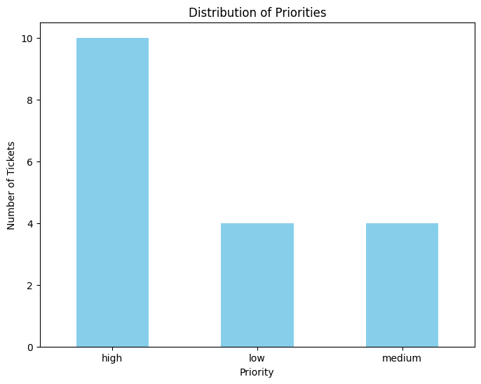

```python
priority_counts = final_data['Priority'].value_counts()
# Plotting the bar chart
priority_counts.plot(kind='bar', figsize=(8, 6), color='skyblue')
plt.title('Distribution of Priorities')
plt.xlabel('Priority')
plt.ylabel('Number of Tickets')
plt.xticks(rotation=0)  # Rotate x-axis labels if needed
plt.show()
```

```python
final_data['ETA'].value_counts()   # complete the code to check the distribution of ETA
```

```
Immediate            10
2-3 business days     4
24 hours              4
Name: ETA, dtype: int64
```

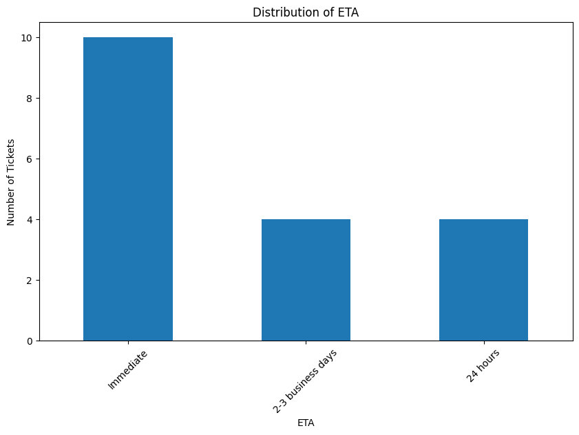

```python
eta_counts = final_data['ETA'].value_counts()

eta_counts.plot(kind='bar', figsize=(10, 6))
plt.title('Distribution of ETA')
plt.xlabel('ETA')
plt.ylabel('Number of Tickets')
plt.xticks(rotation=45)
plt.show()
```

```python
final_data.groupby(['Category', 'Priority']).support_tick_id.count()   # complete the code to check the distribution of priority by categories
```

```
Category          Priority
data recovery     low          4
hardware issues   medium       4
technical issues  high        10
Name: support_tick_id, dtype: int64
```

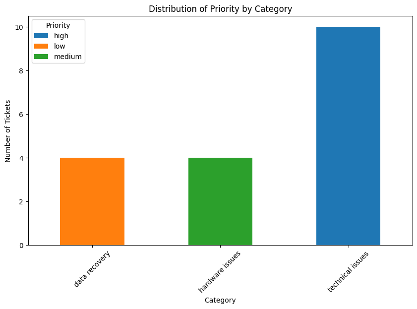

```python
priority_by_category = final_data.groupby(['Category', 'Priority']).support_tick_id.count().unstack()

# Plotting the bar chart
priority_by_category.plot(kind='bar', stacked=True, figsize=(10, 6))
plt.title('Distribution of Priority by Category')
plt.xlabel('Category')
plt.ylabel('Number of Tickets')
plt.xticks(rotation=45)
plt.legend(title='Priority')
plt.show()
```

```python
final_data.groupby(['Category', 'ETA']).support_tick_id.count()   # complete the code to check the distribution of ETA by categories
```

```
Category          ETA
data recovery     2-3 business days     4
hardware issues   24 hours              4
technical issues  Immediate            10
Name: support_tick_id, dtype: int64
```

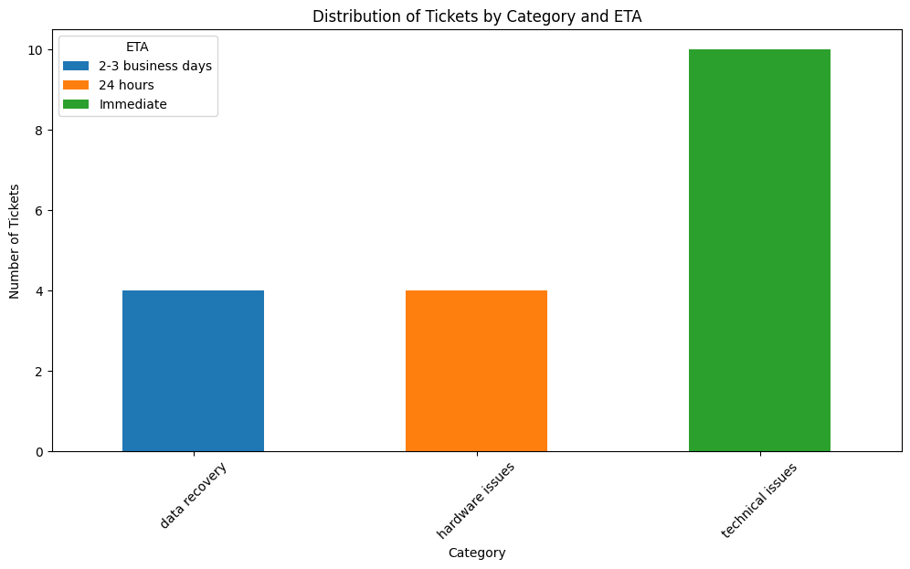

```python
tickets_by_category_eta = final_data.groupby(['Category', 'ETA']).support_tick_id.count().unstack()

# Plotting the bar chart
tickets_by_category_eta.plot(kind='bar', stacked=True, figsize=(12, 6))
plt.title('Distribution of Tickets by Category and ETA')
plt.xlabel('Category')
plt.ylabel('Number of Tickets')
plt.xticks(rotation=45)
plt.legend(title='ETA')
plt.show()
```

**Observations**

- ETA- Most of the issue has immediate ETA.
- Technical issues has high priority tickets.
- Most of the high priority ticket has Immediate category.
- Data recovery has 2-3 days ETA.

## **Actionable Insights and Recommendations**

Model-

1. There are total 21 rows in the data set,but model is able to fetch data only for 18 rows.
2. Need to add more rows to train our model.